# Angle Learning Comprehension analysis

Freya Watkins

2019-07-10

## Pre-processing

Setup markdown file & load packages:

```r
knitr::opts_chunk$set(warning = TRUE, message = FALSE, error=TRUE)
library(tidyverse)
library(car)
library(lme4)
library(afex)
library(emmeans)
library(directlabels)
```

Read in data file. Convert important variables to factors:

```r
angleLearn <- read_csv("2019-07-10 AngleLearningData.csv")
head(angleLearn)
```

```
## # A tibble: 6 x 18
##   Version Subject Session BlockOrder TestAngle Trial  Item Condition Sign
##   <chr>     <dbl>   <dbl>      <dbl> <chr>     <dbl> <dbl> <chr>     <chr>
## 1 V1          205       1          4 45L          59    13 both      HELI~
## 2 V3          217       2          4 45L          60    48 front     PARE~
## 3 V2          320       1          3 45L          35    71 both      ALARM
## 4 V1          102       1          3 45L          45     5 both      LIGH~
## 5 V2          214       2          4 45L          75    67 front     FLAG
## 6 V1          104       1          5 45L          93    91 side      BADM~
## # ... with 9 more variables: Icon <dbl>, Type <chr>, ACC <dbl>,
## #   Error <dbl>, RT <dbl>, RTchecked <dbl>, ExclItem <dbl>, ExclPpt <dbl>,
## #   ExclSlowFast <dbl>
```

```r
angleLearn$Session <- as.factor(angleLearn$Session)
angleLearn$Condition <- as.factor(angleLearn$Condition)
angleLearn$Version <- as.factor(angleLearn$Version)
angleLearn$Type <- as.factor(angleLearn$Type)
angleLearn$Subject <- as.factor(angleLearn$Subject)
```

Check number of subjects and how many data points per subject:

```r
length(unique(angleLearn$Subject))
```

```
## [1] 60
```

```r
summary(angleLearn$Subject)
```

```
## 101 102 103 104 105 106 107 108 109 110 201 202 203 204 205 206 207 208
## 192 192 192 192 192 192 192 192 192 192 192 192 192 192 192 192 192 192
## 209 210 211 212 213 214 215 216 217 218 219 220 221 301 302 304 305 306
## 192 192 192 192 192 192 192 192 192 192 192 192 192 192 192 192 192 192
## 307 309 310 311 312 313 314 315 316 317 318 319 320 321 401 402 403 404
## 192 192 192 192 192 192 192 192 192 192 192 192 192 192 192 192 192 192
## 405 406 407 408 409 410
## 192 192 192 192 192 192
```

60 subjects total. Each subject saw 192 trials across both sessions (96 per session). 6 practice trials (3 per session) have already been excluded from data. No NA values.

Check distribution of experiment versions, and how many times each sign was seen in each of the three learning conditions:

```r
table(angleLearn$Subject, angleLearn$Version)
```

```
##
##        V1  V2  V3
##   101 192   0   0
##   102 192   0   0
##   103 192   0   0
##   104 192   0   0
##   105 192   0   0
##   106   0   0 192
##   107   0   0 192
##   108   0   0 192
##   109   0   0 192
##   110   0   0 192
##   201 192   0   0
##   202 192   0   0
##   203 192   0   0
```

[output cut: 47 more lines]

```r
table(angleLearn$Sign, angleLearn$Condition)
```

```
##
##              both front side
##   ALARM        38    40   42
##   ANIMAL       38    40   42
##   BABY         38    40   42
##   BADMINTON    42    38   40
##   BANDAGE      42    38   40
##   BANK         40    42   38
##   BEANS        42    38   40
##   BED          38    40   42
##   BEEF         42    38   40
##   BELT         40    42   38
##   BISCUIT      38    40   42
##   BOTTLE       38    40   42
##   BOWL         42    38   40
##   BOX          38    40   42
##   BREAD        42    38   40
##   BROOM        40    42   38
##   BROTHER      38    40   42
##   BUS          38    40   42
##   BUTTER       40    42   38
##   CABBAGE      40    42   38
##   CAKE         42    38   40
##   CAR          40    42   38
##   CHILDREN     38    40   42
##   COWBOY       40    42   38
##   CROCODILE    42    38   40
##   DOCTOR       38    40   42
##   DOOR         38    40   42
##   DRILL        40    42   38
##   ELEPHANT     40    42   38
##   FAMILY       40    42   38
##   FATHER       40    42   38
##   FISH         42    38   40
##   FLAG         42    38   40
##   FLOOR        42    38   40
##   FRIEND       42    38   40
##   FROG         38    40   42
##   GARDEN       40    42   38
##   GRAPES       40    42   38
```

[output cut: 43 more lines]

```
##   THEATRE      38    40   42
##   TIME         38    40   42
##   TOILET       40    42   38
##   TOMATO       42    38   40
##   TOMORROW     38    40   42
##   TOWEL        38    40   42
##   TRAFFIC      42    38   40
##   TRAIN        40    42   38
##   TREE         40    42   38
##   UMBRELLA     38    40   42
##   VIOLIN       40    42   38
##   WALL         42    38   40
##   WAR          40    42   38
##   WEEK         40    42   38
##   WINDOW       42    38   40
```

20 participants did Version 1; 19 did version 2 & 21 did version 3.

Number of unique signs:

```r
length(unique(angleLearn$Sign))
```

```
## [1] 96
```

Check number of data points per sign:

```r
table(angleLearn$Sign)
```

```
##
##      ALARM     ANIMAL       BABY  BADMINTON    BANDAGE       BANK
##        120        120        120        120        120        120
##      BEANS        BED       BEEF       BELT    BISCUIT     BOTTLE
##        120        120        120        120        120        120
##       BOWL        BOX      BREAD      BROOM    BROTHER        BUS
##        120        120        120        120        120        120
##     BUTTER    CABBAGE       CAKE        CAR   CHILDREN     COWBOY
##        120        120        120        120        120        120
##  CROCODILE     DOCTOR       DOOR      DRILL   ELEPHANT     FAMILY
##        120        120        120        120        120        120
##     FATHER       FISH       FLAG      FLOOR     FRIEND       FROG
##        120        120        120        120        120        120
##     GARDEN     GRAPES      GRASS     HAMMER HELICOPTER      HORSE
##        120        120        120        120        120        120
##  INJECTION     JUMPER    LIGHTER      MATCH       MEAT   MECHANIC
##        120        120        120        120        120        120
##   MEDICINE       MILK      MONEY     MONKEY    MORNING  MOTORBIKE
##        120        120        120        120        120        120
##   MOUNTAIN       NAME    PARENTS       PEAS     PENCIL    PERFUME
##        120        120        120        120        120        120
##     PERSON      PIZZA      PLANE     POLICE        PUB     RABBIT
##        120        120        120        120        120        120
##       RAKE      RIVER       ROAD      ROBOT       ROOM      SALAD
##        120        120        120        120        120        120
##   SANDWICH   SCISSORS     SHORTS     SHOWER  SPAGHETTI     STAIRS
##        120        120        120        120        120        120
##  SUBTITLES      SUGAR        SUN    THEATRE       TIME     TOILET
##        120        120        120        120        120        120
##     TOMATO   TOMORROW      TOWEL    TRAFFIC      TRAIN       TREE
##        120        120        120        120        120        120
##   UMBRELLA     VIOLIN       WALL        WAR       WEEK     WINDOW
##        120        120        120        120        120        120
```

There are 96 signs overall. Each one was tested 120 times overall (60 participants at session 1; same 60 participants at session 2)

Any signs without 120 data points per subject?

```r
which(table(angleLearn$Sign) != 120)
```

```
## named integer(0)
```

No

# Accuracy analysis

1. Check participant accuracy:

First calculate accuracy per participant and per session:

```r
ppt_acc_S1 <- filter(angleLearn, Session == 1) %>% group_by(Subject) %>%
     summarize(ACC = mean(ACC))
ppt_acc_S1
```

```
## # A tibble: 60 x 2
##    Subject   ACC
##    <fct>   <dbl>
##  1 101     0.885
##  2 102     0.927
##  3 103     0.958
##  4 104     0.896
##  5 105     0.885
##  6 106     0.958
##  7 107     0.729
##  8 108     0.938
##  9 109     0.854
## 10 110     0.781
## # ... with 50 more rows
```

```r
ppt_acc_S2 <- filter(angleLearn, Session == 2) %>% group_by(Subject) %>%
     summarize(ACC = mean(ACC))
ppt_acc_S2
```

```
## # A tibble: 60 x 2
##    Subject   ACC
##    <fct>   <dbl>
##  1 101     0.833
##  2 102     0.781
##  3 103     0.635
##  4 104     0.552
##  5 105     0.698
##  6 106     0.896
##  7 107     0.552
##  8 108     0.812
##  9 109     0.646
## 10 110     0.656
## # ... with 50 more rows
```

Which participants had <70% accuracy at Session 1?

```r
ppt_acc_S1[(ppt_acc_S1[,2] <0.70),]
```

```
## # A tibble: 3 x 2
##   Subject   ACC
##   <fct>   <dbl>
## 1 215     0.677
## 2 314     0.688
## 3 320     0.490
```

3 participants had <70% accuracy at Session 1.

Exclude these participants from further analysis:

```r
#angleLearn <- filter(angleLearn, ExclPpt != 1)
#angleLearn
```

2. Check item accuracy:

First calculate accuracy per item and per session:

```r
item_acc_S1 <- filter(angleLearn, Session == 1) %>% group_by(Sign) %>% summarize(ACC = mean(ACC))
item_acc_S1
```

```
## # A tibble: 96 x 2
##    Sign        ACC
##    <chr>     <dbl>
##  1 ALARM     0.633
##  2 ANIMAL    0.967
##  3 BABY      1
##  4 BADMINTON 0.95
##  5 BANDAGE   0.983
##  6 BANK      0.533
##  7 BEANS     0.533
##  8 BED       1
##  9 BEEF      0.633
## 10 BELT      1
## # ... with 86 more rows
```

```r
item_acc_S2 <- filter(angleLearn, Session == 2) %>% group_by(Sign) %>% summarize(ACC = mean(ACC))
item_acc_S2
```

```
## # A tibble: 96 x 2
##    Sign        ACC
##    <chr>     <dbl>
##  1 ALARM     0.217
##  2 ANIMAL    0.783
##  3 BABY      1
##  4 BADMINTON 0.867
##  5 BANDAGE   0.9
##  6 BANK      0.35
##  7 BEANS     0.15
##  8 BED       0.617
##  9 BEEF      0.433
## 10 BELT      1
## # ... with 86 more rows
```

Which items had below 60% accuracy at Session 1?

```r
item_acc_S1[(item_acc_S1[,2] <0.6),]
```

```
## # A tibble: 4 x 2
##   Sign     ACC
##   <chr>  <dbl>
## 1 BANK   0.533
## 2 BEANS  0.533
## 3 CAR    0.55
## 4 FATHER 0.483
```

4 items had <60% accuracy at Session 1 (4% total items)

Exclude these items from further analysis:

```r
#angleLearn <- filter(angleLearn,
#            ExclItem != 1)
#angleLearn
```

Calculate accuracy averages by condition and session, recalculate by-subject averages:

```r
angleLearn %>% group_by(Condition, Session) %>%
  summarize(ACC = mean(ACC))
```

```
## # A tibble: 6 x 3
## # Groups:   Condition [3]
##   Condition Session   ACC
##   <fct>     <fct>   <dbl>
## 1 both      1       0.881
## 2 both      2       0.696
## 3 front     1       0.881
## 4 front     2       0.678
## 5 side      1       0.856
## 6 side      2       0.680
```

```r
ppt_acc_S1 <- filter(angleLearn, Session == 1) %>% group_by(Subject) %>%
     summarize(ACC = mean(ACC))
ppt_acc_S2 <- filter(angleLearn, Session == 2) %>% group_by(Subject) %>%
     summarize(ACC = mean(ACC))
```

Looks like no significant differences in accuracy across conditions at either session. Side is worst at Session 1, Front is worst as Session 2. Overall accuacy drops ~17-20% between S1 and S2.

Plot Accuracy data:

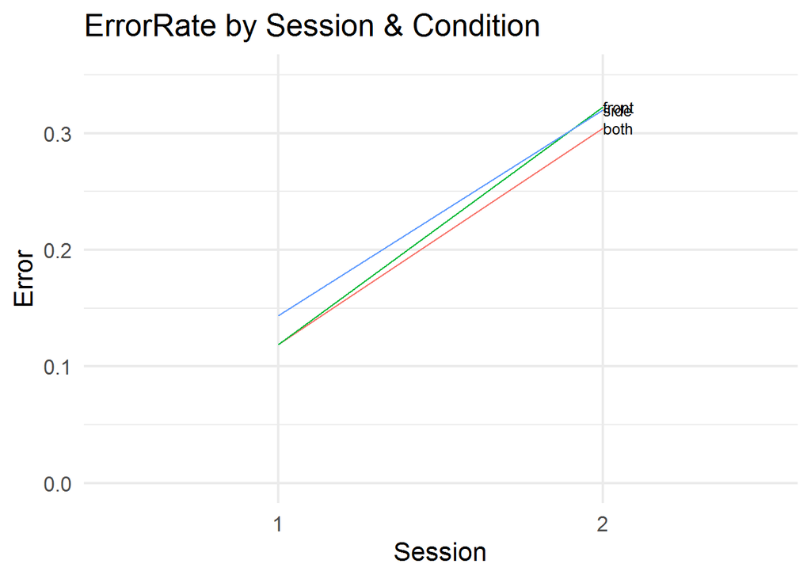

```r
angleLearn %>% group_by(Session, Condition) %>%
  summarize(Error = mean(Error)) %>%
  ggplot + geom_line(aes(x = Session, y = Error, group = Condition,
                         colour = Condition)) +
  coord_cartesian(ylim = c(0,0.35)) +
  geom_dl(aes(x = Session, y = Error, label = Condition), method = list(dl.combine("last.points"), cex = 0.8)) +
  theme_minimal(base_size = 16) +
  theme(legend.position = "none") +
  ggtitle('ErrorRate by Session & Condition')
```

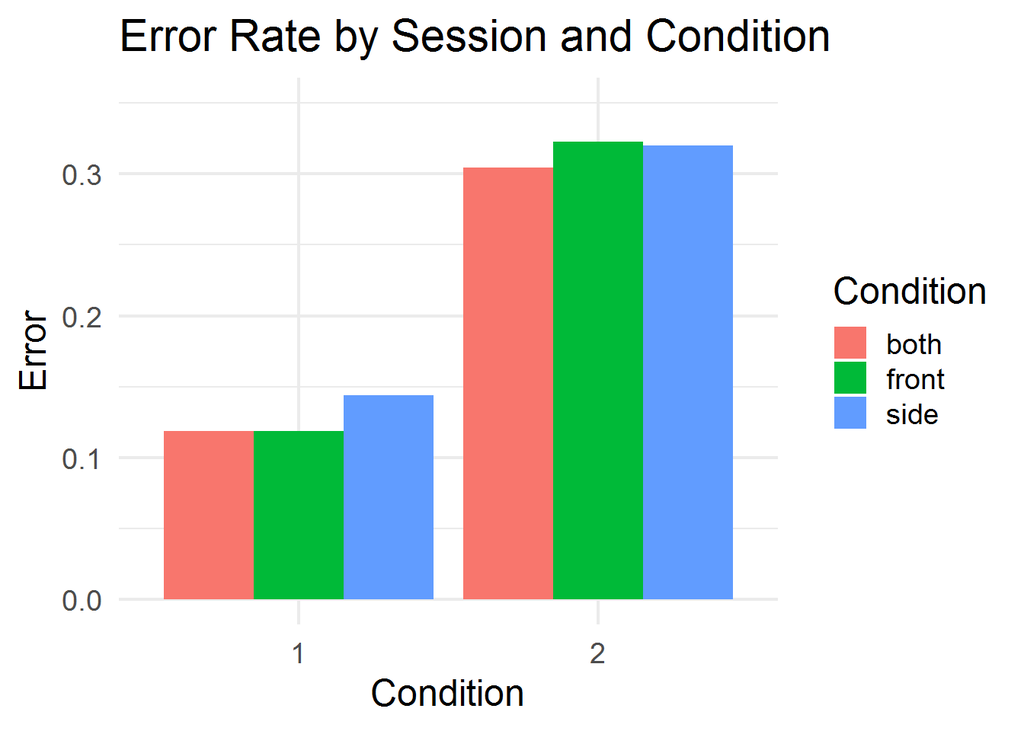

```r
angleLearn %>% group_by(Session, Condition) %>%
  summarize(Error = mean(Error)) %>%
  ggplot(aes(x = factor(Session, level = c("1", "2")),
             y = Error, fill = Condition)) +
  geom_bar(stat = 'identity', position = position_dodge()) +
  coord_cartesian(ylim = c(0, 0.35)) +
  theme_minimal(base_size = 18) +
  ggtitle('Error Rate by Session and Condition') + xlab('Condition')
```

```r
lmer.ACC <- mixed(ACC ~ Condition*Session + (1 + Condition|Subject) +
                    (1 + Condition|Sign),
                  angleLearn, all_fit = TRUE, method = "LRT",
                  control = lmerControl(optCtrl = list(maxfun = 1e6)))
```

```
## Fitting 4 (g)lmer() models:
## [...
```

```
## .]
```

```
## Error in anova.merMod(full_model, fits[[c]]): all models must be fit to the same data object
```

```r
lmer.ACC
```

```
## Error in eval(expr, envir, enclos): object 'lmer.ACC' not found
```

```r
emmACC <- emmeans(lmer.ACC, specs = ~ Session:Condition, data = angleLearn)
```

```
## Error in is(object, "emmGrid"): object 'lmer.ACC' not found
```

```r
emmACC
```

```
## Error in eval(expr, envir, enclos): object 'emmACC' not found
```

```r
Both1 <- c(1, 0, 0, 0, 0, 0)
Side1 <- c(0, 0, 0, 0, 1, 0)
Front1 <- c(0, 0, 1, 0, 0, 0)
contrast(emmACC, method = list("Both1 - Side1" = Both1 - Side1,
                             "Both1 - Front1" = Both1 - Front1,
                             "Side1 - Front1" = Side1 - Front1), adjust = "mvt")
```

```
## Error in contrast(emmACC, method = list(`Both1 - Side1` = Both1 - Side1, : object 'emmACC' not found
```

```r
Both2 <- c(0, 1, 0, 0, 0, 0)
Side2 <- c(0, 0, 0, 0, 0, 1)
Front2 <- c(0, 0, 0, 1, 0, 0)
contrast(emmACC, method = list("Both2 - Side2" = Both2 - Side2,
                             "Both2 - Front2" = Both2 - Front2,
                             "Side2 - Front2" = Side2 - Front2), adjust = "mvt")
```

```
## Error in contrast(emmACC, method = list(`Both2 - Side2` = Both2 - Side2, : object 'emmACC' not found
```

## Sign Type Acc analysis

Sign Type model:

```r
type.ACC <- mixed(ACC ~ Condition*Session + Type + (1 + Condition | Subject) +
                   (1 + Condition|Sign), angleLearn, all_fit = TRUE,
                 method = "LRT", control = lmerControl(optCtrl = list(maxfun = 1e6)))
```

```
## Fitting 5 (g)lmer() models:
## [.
```

```
## .
```

```
## ..
```

```
## .]
```

```
## Error in anova.merMod(full_model, fits[[c]]): all models must be fit to the same data object
```

```r
type.ACC
```

```
## Error in eval(expr, envir, enclos): object 'type.ACC' not found
```

```r
anova(type.ACC)
```

```
## Error in anova(type.ACC): object 'type.ACC' not found
```

Sign Type model without Session:

```r
type2.ACC <- mixed(ACC ~ Condition*Type + (1 + Condition | Subject) +
                         (1 + Condition|Sign), angleLearn, all_fit = TRUE,
                       method = "LRT", control = lmerControl(optCtrl = list(maxfun = 1e6)))
```

```
## Fitting 4 (g)lmer() models:
## [
```

```
## ...
```

```
## .]
```

```
## Error in anova.merMod(full_model, fits[[c]]): all models must be fit to the same data object
```

```r
type2.ACC
```

```
## Error in eval(expr, envir, enclos): object 'type2.ACC' not found
```

```r
anova(type2.ACC)
```

```
## Error in anova(type2.ACC): object 'type2.ACC' not found
```

## Iconicity Acc analysis

Filter out signs with no iconicity ratings:

```r
iconicityACC <- filter(angleLearn, Icon != 0)
iconicityACC
```

```
## # A tibble: 9,000 x 18
##    Version Subject Session BlockOrder TestAngle Trial  Item Condition Sign
##    <fct>   <fct>   <fct>        <dbl> <chr>     <dbl> <dbl> <fct>     <chr>
##  1 V1      205     1                4 45L          59    13 both      HELI~
##  2 V3      217     2                4 45L          60    48 front     PARE~
##  3 V2      320     1                3 45L          35    71 both      ALARM
##  4 V1      102     1                3 45L          45     5 both      LIGH~
##  5 V2      214     2                4 45L          75    67 front     FLAG
##  6 V1      203     1                3 45L          40    12 front     BOTT~
##  7 V2      319     2                5 45L          89    45 side      GRAP~
##  8 V2      405     1                4 45L          74     2 side      DRILL
##  9 V3      311     1                5 45L          86     7 side      SCIS~
## 10 V2      207     2                5 45L          95    18 both      BABY
## # ... with 8,990 more rows, and 9 more variables: Icon <dbl>, Type <fct>,
## #   ACC <dbl>, Error <dbl>, RT <dbl>, RTchecked <dbl>, ExclItem <dbl>,
## #   ExclPpt <dbl>, ExclSlowFast <dbl>
```

Model with iconicity ratings:

```r
icon.ACC <- mixed(ACC ~ Condition*Session + Icon + (1 + Condition | Subject) +
                   (1 + Condition|Sign), iconicityACC, all_fit = TRUE,
                 method = "L", control = lmerControl(optCtrl = list(maxfun = 1e6)))
```

```
## Fitting 5 (g)lmer() models:
## [
```

```
## .
```

```
## .
```

```
## ..
```

```
## .]
```

```
## Error in anova.merMod(full_model, fits[[c]]): all models must be fit to the same data object
```

```r
icon.ACC
```

```
## Error in eval(expr, envir, enclos): object 'icon.ACC' not found
```

```r
anova(icon.ACC)
```

```
## Error in anova(icon.ACC): object 'icon.ACC' not found
```

Iconicity model without Session:

```r
icon2.ACC <- mixed(ACC ~ Condition*Icon + (1 + Condition | Subject) +
                         (1 + Condition|Sign), iconicityACC, all_fit = TRUE,
                       method = "LRT", control = lmerControl(optCtrl = list(maxfun = 1e6)))
```

```
## Fitting 4 (g)lmer() models:
## [...
```

```
## .]
```

```
## Error in anova.merMod(full_model, fits[[c]]): all models must be fit to the same data object
```

```r
icon2.ACC
```

```
## Error in eval(expr, envir, enclos): object 'icon2.ACC' not found
```

```r
anova(icon2.ACC)
```

```
## Error in anova(icon2.ACC): object 'icon2.ACC' not found
```

# RT analysis

1. Exclude any inaccurate trials:

```r
angleLearnRT <- filter(angleLearn,
             ACC == 1)
angleLearnRT
```

```
## # A tibble: 8,971 x 18
##    Version Subject Session BlockOrder TestAngle Trial  Item Condition Sign
##    <fct>   <fct>   <fct>        <dbl> <chr>     <dbl> <dbl> <fct>     <chr>
##  1 V1      205     1                4 45L          59    13 both      HELI~
##  2 V1      102     1                3 45L          45     5 both      LIGH~
##  3 V2      214     2                4 45L          75    67 front     FLAG
##  4 V1      104     1                5 45L          93    91 side      BADM~
##  5 V1      203     1                3 45L          40    12 front     BOTT~
##  6 V3      311     1                5 45L          86     7 side      SCIS~
##  7 V2      207     2                5 45L          95    18 both      BABY
##  8 V1      105     2                4 45L          59    23 side      CROC~
##  9 V2      409     1                5 45L          81    63 front     BEANS
## 10 V2      317     1                3 45L          41     5 side      LIGH~
## # ... with 8,961 more rows, and 9 more variables: Icon <dbl>, Type <fct>,
## #   ACC <dbl>, Error <dbl>, RT <dbl>, RTchecked <dbl>, ExclItem <dbl>,
## #   ExclPpt <dbl>, ExclSlowFast <dbl>
```

2. Exclude any trials +/- 2 SD from session mean

```r
# angleLearnRT %>% group_by(Session) %>%
#  summarize(RT = mean(RT))
#angleLearnRT %>% group_by(Session) %>%
#  summarize(sd2 = (sd(RT))*2)
#angleLearnRT <- filter(angleLearnRT,
#              ExclSlowFast != 1)
#angleLearnRT
```

3. Are any participants particularly fast or slow? (M +/- 2SD)

First calculate mean RT per participant per session:

```r
ppt_rt_S1 <- filter(angleLearnRT, Session == 1) %>% group_by(Subject) %>%
     summarize(RT = mean(RT))
ppt_rt_S1
```

```
## # A tibble: 60 x 2
##    Subject    RT
##    <fct>   <dbl>
##  1 101     2095.
##  2 102     1758.
##  3 103     1841.
##  4 104     1812.
##  5 105     1682.
##  6 106     1833.
##  7 107     1940.
##  8 108     1702.
##  9 109     2019.
## 10 110     2031.
## # ... with 50 more rows
```

```r
ppt_rt_S2 <- filter(angleLearnRT, Session == 2) %>% group_by(Subject) %>%
     summarize(RT = mean(RT))
ppt_rt_S2
```

```
## # A tibble: 60 x 2
##    Subject    RT
##    <fct>   <dbl>
##  1 101     2192.
##  2 102     2094.
##  3 103     2107.
##  4 104     2148.
##  5 105     2019.
##  6 106     1959.
##  7 107     2187.
##  8 108     2163.
##  9 109     2375.
## 10 110     2288.
## # ... with 50 more rows
```

Then compare to session mean RT +/- 2 SD :

```r
angleLearnRT %>% group_by(Session) %>%
  summarize(RT = mean(RT))
```

```
## # A tibble: 2 x 2
##   Session    RT
##   <fct>   <dbl>
## 1 1       1890.
## 2 2       2205.
```

```r
angleLearnRT %>% group_by(Session) %>%
  summarize(sd2 = (sd(RT))*2)
```

```
## # A tibble: 2 x 2
##   Session   sd2
##   <fct>   <dbl>
## 1 1        892.
## 2 2       1035.
```

No participants have mean RTs at either session +/- 2SDs of the Session mean RT; none were excluded

4. Were any items particularly fast or slow?

```r
item_rt_S1 <- filter(angleLearnRT, Session == 1) %>% group_by(Sign) %>%
     summarize(RT = mean(RT))
item_rt_S1
```

```
## # A tibble: 96 x 2
##    Sign         RT
##    <chr>     <dbl>
##  1 ALARM     2195.
##  2 ANIMAL    1716.
##  3 BABY      1431.
##  4 BADMINTON 2030.
##  5 BANDAGE   1570.
##  6 BANK      2353.
##  7 BEANS     2171.
##  8 BED       1687.
##  9 BEEF      2253.
## 10 BELT      1491.
## # ... with 86 more rows
```

```r
item_rt_S2 <- filter(angleLearnRT, Session == 2) %>% group_by(Sign) %>%
     summarize(RT = mean(RT))
item_rt_S2
```

```
## # A tibble: 96 x 2
##    Sign         RT
##    <chr>     <dbl>
##  1 ALARM     2523.
##  2 ANIMAL    2185.
##  3 BABY      1690.
##  4 BADMINTON 2328.
##  5 BANDAGE   2071.
##  6 BANK      2401.
##  7 BEANS     2456.
##  8 BED       2321.
##  9 BEEF      2521.
## 10 BELT      1844.
## # ... with 86 more rows
```

No items have mean RTs at either session +/- 2SDs of the Session mean RT; none were excluded.

Calculate RT averages by Condition and Session:

```r
angleLearnRT %>% group_by(Condition, Session) %>%
  summarize(RT = mean(RT))
```

```
## # A tibble: 6 x 3
## # Groups:   Condition [3]
##   Condition Session    RT
##   <fct>     <fct>   <dbl>
## 1 both      1       1873.
## 2 both      2       2218.
## 3 front     1       1893.
## 4 front     2       2196.
## 5 side      1       1904.
## 6 side      2       2199.
```

Plot RT data:

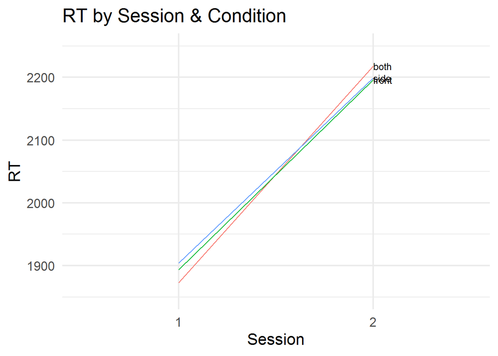

```r
angleLearnRT %>% group_by(Session, Condition) %>%
  summarize(RT = mean(RT)) %>%
  ggplot + geom_line(aes(x = Session, y = RT, group = Condition,
                         colour = Condition)) +
  coord_cartesian(ylim = c(1850,2250)) +
  geom_dl(aes(x = Session, y = RT, label = Condition),
          method = list(dl.combine("last.points"), cex = 0.8)) +
  theme_minimal(base_size = 16) +
  theme(legend.position = "none") +
  ggtitle('RT by Session & Condition')
```

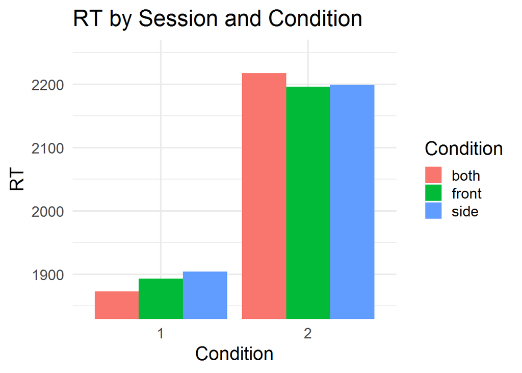

```r
angleLearnRT %>% group_by(Session, Condition) %>%
  summarize(RT = mean(RT)) %>%
  ggplot(aes(x = factor(Session, level = c("1", "2")),
             y = RT, fill = Condition)) +
  geom_bar(stat = 'identity', position = position_dodge()) +
  coord_cartesian(ylim = c(1850, 2250)) +
  theme_minimal(base_size = 18) +
  ggtitle('RT by Session and Condition') + xlab('Condition')
```

Linear model for RT:

```r
lmer.RT <- mixed(RT ~ Condition*Session + (1 + Condition| Subject) +
                   (1 + Condition|Sign),
                 angleLearnRT, all_fit = TRUE, method = "LRT",
                 control = lmerControl(optCtrl = list(maxfun = 1e6)))
```

```
## Fitting 4 (g)lmer() models:
## [...
```

```
## .]
```

```r
lmer.RT
```

```
## Mixed Model Anova Table (Type 3 tests, LRT-method)
##
## Model: RT ~ Condition * Session + (1 + Condition | Subject) + (1 + Condition |
## Model:     Sign)
## Data: angleLearnRT
## Df full model: 19
##              Effect df       Chisq p.value
## 1         Condition  2        1.78     .41
## 2           Session  1 1508.73 ***  <.0001
## 3 Condition:Session  2      6.79 *     .03
## ---
## Signif. codes:  0 '***' 0.001 '**' 0.01 '*' 0.05 '+' 0.1 ' ' 1
```

```r
anova(lmer.RT)
```

```
## Mixed Model Anova Table (Type 3 tests, LRT-method)
##
## Model: RT ~ Condition * Session + (1 + Condition | Subject) + (1 + Condition |
## Model:     Sign)
## Data: angleLearnRT
## Df full model: 19
##                   Df     Chisq Chi Df Pr(>Chisq)
## Condition         17    1.7820      2    0.41025
## Session           18 1508.7297      1    < 2e-16 ***
## Condition:Session 17    6.7852      2    0.03362 *
## ---
## Signif. codes:  0 '***' 0.001 '**' 0.01 '*' 0.05 '.' 0.1 ' ' 1
```

Pairwise analysis of conditions at session 1 and session 2:

```r
emm1 <- emmeans(lmer.RT, specs = ~ Session:Condition, data = angleLearnRT)
Both1 <- c(1, 0, 0, 0, 0, 0)
Side1 <- c(0, 0, 0, 0, 1, 0)
Front1 <- c(0, 0, 1, 0, 0, 0)
Both2 <- c(0, 1, 0, 0, 0, 0)
Side2 <- c(0, 0, 0, 0, 0, 1)
Front2 <- c(0, 0, 0, 1, 0, 0)
contrast(emm1, method = list("Both1 - Side1" = Both1 - Side1,
                             "Both1 - Front1" = Both1 - Front1,
                             "Side1 - Front1" = Side1 - Front1), adjust = "mvt")
```

```
##  contrast       estimate   SE  df z.ratio p.value
##  Both1 - Side1     -43.3 15.7 Inf -2.762  0.0160
##  Both1 - Front1    -22.4 15.1 Inf -1.479  0.3009
##  Side1 - Front1     20.9 15.7 Inf  1.328  0.3795
##
## P value adjustment: mvt method for 3 tests
```

```r
contrast(emm1, method = list("Both2 - Side2" = Both2 - Side2,
                             "Both2 - Front2" = Both2 - Front2,
                             "Side2 - Front2" = Side2 - Front2), adjust = "mvt")
```

```
##  contrast       estimate   SE  df z.ratio p.value
##  Both2 - Side2     10.26 17.3 Inf 0.592   0.8244
##  Both2 - Front2    15.80 17.0 Inf 0.932   0.6201
##  Side2 - Front2     5.54 17.5 Inf 0.317   0.9462
##
## P value adjustment: mvt method for 3 tests
```

Log-transform reaction times:

```r
angleLearnLogRT <- mutate(angleLearnRT, Log10RT = log10(RT))
```

Log-transformed RT linear model:

```r
lmer.logRT <- mixed(Log10RT ~ Condition*Session + (1 | Subject) +
                   (1 + Condition|Sign),
                 angleLearnLogRT, all_fit = TRUE, method = "LRT",
                 control = lmerControl(optCtrl = list(maxfun = 1e6)))
```

```
## Fitting 4 (g)lmer() models:
## [....]
```

```r
lmer.logRT
```

```
## Mixed Model Anova Table (Type 3 tests, LRT-method)
##
## Model: Log10RT ~ Condition * Session + (1 | Subject) + (1 + Condition |
## Model:     Sign)
## Data: angleLearnLogRT
## Df full model: 14
##              Effect df       Chisq p.value
## 1         Condition  2        2.47     .29
## 2           Session  1 1712.31 ***  <.0001
## 3 Condition:Session  2      6.81 *     .03
## ---
## Signif. codes:  0 '***' 0.001 '**' 0.01 '*' 0.05 '+' 0.1 ' ' 1
```

```r
anova(lmer.logRT)
```

```
## Mixed Model Anova Table (Type 3 tests, LRT-method)
##
## Model: Log10RT ~ Condition * Session + (1 | Subject) + (1 + Condition |
## Model:     Sign)
## Data: angleLearnLogRT
## Df full model: 14
##                   Df     Chisq Chi Df Pr(>Chisq)
## Condition         12    2.4706      2    0.29075
## Session           13 1712.3059      1    < 2e-16 ***
## Condition:Session 12    6.8080      2    0.03324 *
## ---
## Signif. codes:  0 '***' 0.001 '**' 0.01 '*' 0.05 '.' 0.1 ' ' 1
```

LogRT pairwise analysis of conditions at session 1 and session 2:

```r
emm2 <- emmeans(lmer.logRT, specs = ~ Session:Condition, data = angleLearnLogRT)

Both1 <- c(1, 0, 0, 0, 0, 0)
Side1 <- c(0, 0, 0, 0, 1, 0)
Front1 <- c(0, 0, 1, 0, 0, 0)
contrast(emm2, method = list("Both1 - Side1" = Both1 - Side1,
                              "Both1 - Front1" = Both1 - Front1,
                              "Side1 - Front1" = Side1 - Front1), adjust = "mvt")
```

```
##  contrast       estimate      SE  df z.ratio p.value
##  Both1 - Side1  -0.00924 0.00309 Inf -2.985  0.0079
##  Both1 - Front1 -0.00505 0.00294 Inf -1.718  0.1984
##  Side1 - Front1  0.00418 0.00313 Inf  1.339  0.3733
##
## P value adjustment: mvt method for 3 tests
```

```r
Both2 <- c(0, 1, 0, 0, 0, 0)
Side2 <- c(0, 0, 0, 0, 0, 1)
Front2 <- c(0, 0, 0, 1, 0, 0)
contrast(emm2, method = list("Both2 - Side2" = Both2 - Side2,
                              "Both2 - Front2" = Both2 - Front2,
                              "Side2 - Front2" = Side2 - Front2), adjust = "mvt")
```

```
##  contrast       estimate      SE  df z.ratio p.value
##  Both2 - Side2   0.00129 0.00342 Inf 0.377   0.9246
##  Both2 - Front2  0.00256 0.00330 Inf 0.777   0.7171
##  Side2 - Front2  0.00127 0.00347 Inf 0.367   0.9284
##
## P value adjustment: mvt method for 3 tests
```

## Sign Type RT analysis

Sign Type model:

```r
type.RT <- mixed(RT ~ Condition*Session + Type + (1 + Condition | Subject) +
                   (1 + Condition|Sign), angleLearnRT, all_fit = TRUE,
                 method = "LRT", control = lmerControl(optCtrl = list(maxfun = 1e6)))
```

```
## Fitting 5 (g)lmer() models:
## [.....]
```

```r
type.RT
```

```
## Mixed Model Anova Table (Type 3 tests, LRT-method)
##
## Model: RT ~ Condition * Session + Type + (1 + Condition | Subject) +
## Model:     (1 + Condition | Sign)
## Data: angleLearnRT
## Df full model: 21
##              Effect df       Chisq p.value
## 1         Condition  2        1.79     .41
## 2           Session  1 1508.46 ***  <.0001
## 3              Type  2      6.80 *     .03
## 4 Condition:Session  2      6.80 *     .03
## ---
## Signif. codes:  0 '***' 0.001 '**' 0.01 '*' 0.05 '+' 0.1 ' ' 1
```

```r
anova(type.RT)
```

```
## Mixed Model Anova Table (Type 3 tests, LRT-method)
##
## Model: RT ~ Condition * Session + Type + (1 + Condition | Subject) +
## Model:     (1 + Condition | Sign)
## Data: angleLearnRT
## Df full model: 21
##                   Df     Chisq Chi Df Pr(>Chisq)
## Condition         19    1.7900      2     0.4086
## Session           20 1508.4599      1     <2e-16 ***
## Type              19    6.8042      2     0.0333 *
## Condition:Session 19    6.7981      2     0.0334 *
## ---
## Signif. codes:  0 '***' 0.001 '**' 0.01 '*' 0.05 '.' 0.1 ' ' 1
```

Sign Type model without Session:

```r
type2.RT <- mixed(RT ~ Condition*Type + (1 + Condition | Subject) +
                         (1 + Condition|Sign), angleLearnRT, all_fit = TRUE,
                       method = "LRT", control = lmerControl(optCtrl = list(maxfun = 1e6)))
```

```
## Fitting 4 (g)lmer() models:
## [....]
```

```r
type2.RT
```

```
## Mixed Model Anova Table (Type 3 tests, LRT-method)
##
## Model: RT ~ Condition * Type + (1 + Condition | Subject) + (1 + Condition |
## Model:     Sign)
## Data: angleLearnRT
## Df full model: 22
##           Effect df  Chisq p.value
## 1      Condition  2   2.59     .27
## 2           Type  2 7.08 *     .03
## 3 Condition:Type  4   3.69     .45
## ---
## Signif. codes:  0 '***' 0.001 '**' 0.01 '*' 0.05 '+' 0.1 ' ' 1
```

```r
anova(type2.RT)
```

```
## Mixed Model Anova Table (Type 3 tests, LRT-method)
##
## Model: RT ~ Condition * Type + (1 + Condition | Subject) + (1 + Condition |
## Model:     Sign)
## Data: angleLearnRT
## Df full model: 22
##                Df  Chisq Chi Df Pr(>Chisq)
## Condition      20 2.5933      2    0.27345
## Type           20 7.0790      2    0.02903 *
## Condition:Type 18 3.6853      4    0.45027
## ---
## Signif. codes:  0 '***' 0.001 '**' 0.01 '*' 0.05 '.' 0.1 ' ' 1
```

## Iconicity RT analysis

Filter out signs with no iconicity ratings:

```r
iconicityRT <- filter(angleLearnRT, Icon != 0)
iconicityRT
```

```
## # A tibble: 7,097 x 18
##    Version Subject Session BlockOrder TestAngle Trial  Item Condition Sign
##    <fct>   <fct>   <fct>        <dbl> <chr>     <dbl> <dbl> <fct>     <chr>
##  1 V1      205     1                4 45L          59    13 both      HELI~
##  2 V1      102     1                3 45L          45     5 both      LIGH~
##  3 V2      214     2                4 45L          75    67 front     FLAG
##  4 V1      203     1                3 45L          40    12 front     BOTT~
##  5 V3      311     1                5 45L          86     7 side      SCIS~
##  6 V2      207     2                5 45L          95    18 both      BABY
##  7 V1      105     2                4 45L          59    23 side      CROC~
##  8 V2      317     1                3 45L          41     5 side      LIGH~
##  9 V3      218     2                2 45L          22    46 both      GRASS
## 10 V3      310     1                5 45L          85    38 both      PERS~
## # ... with 7,087 more rows, and 9 more variables: Icon <dbl>, Type <fct>,
## #   ACC <dbl>, Error <dbl>, RT <dbl>, RTchecked <dbl>, ExclItem <dbl>,
## #   ExclPpt <dbl>, ExclSlowFast <dbl>
```

Model with iconicity ratings:

```r
icon.RT <- mixed(RT ~ Condition*Session + Icon + (1 + Condition | Subject) +
                   (1 + Condition|Sign), iconicityRT, all_fit = TRUE,
                 method = "LRT", control = lmerControl(optCtrl = list(maxfun = 1e6)))
```

```
## Fitting 5 (g)lmer() models:
## [.....]
```

```r
icon.RT
```

```
## Mixed Model Anova Table (Type 3 tests, LRT-method)
##
## Model: RT ~ Condition * Session + Icon + (1 + Condition | Subject) +
## Model:     (1 + Condition | Sign)
## Data: iconicityRT
## Df full model: 20
##              Effect df       Chisq p.value
## 1         Condition  2        1.96     .37
## 2           Session  1 1206.97 ***  <.0001
## 3              Icon  1   22.17 ***  <.0001
## 4 Condition:Session  2      4.64 +     .10
## ---
## Signif. codes:  0 '***' 0.001 '**' 0.01 '*' 0.05 '+' 0.1 ' ' 1
```

```r
anova(icon.RT)
```

```
## Mixed Model Anova Table (Type 3 tests, LRT-method)
##
## Model: RT ~ Condition * Session + Icon + (1 + Condition | Subject) +
## Model:     (1 + Condition | Sign)
## Data: iconicityRT
## Df full model: 20
##                   Df     Chisq Chi Df Pr(>Chisq)
## Condition         18    1.9625      2     0.3748
## Session           19 1206.9701      1  < 2.2e-16 ***
## Icon              19   22.1716      1  2.493e-06 ***
## Condition:Session 18    4.6395      2     0.0983 .
## ---
## Signif. codes:  0 '***' 0.001 '**' 0.01 '*' 0.05 '.' 0.1 ' ' 1
```

Iconicity model without Session:

```r
icon2.RT <- mixed(RT ~ Condition*Icon + (1 + Condition | Subject) +
                         (1 + Condition|Sign), iconicityRT, all_fit = TRUE,
                       method = "LRT", control = lmerControl(optCtrl = list(maxfun = 1e6)))
```

```
## Fitting 4 (g)lmer() models:
## [....]
```

```r
icon2.RT
```

```
## Mixed Model Anova Table (Type 3 tests, LRT-method)
##
## Model: RT ~ Condition * Icon + (1 + Condition | Subject) + (1 + Condition |
## Model:     Sign)
## Data: iconicityRT
## Df full model: 19
##           Effect df     Chisq p.value
## 1      Condition  2      1.25     .54
## 2           Icon  1 20.40 ***  <.0001
## 3 Condition:Icon  2      1.50     .47
## ---
## Signif. codes:  0 '***' 0.001 '**' 0.01 '*' 0.05 '+' 0.1 ' ' 1
```

```r
anova(icon2.RT)
```

```
## Mixed Model Anova Table (Type 3 tests, LRT-method)
##
## Model: RT ~ Condition * Icon + (1 + Condition | Subject) + (1 + Condition |
## Model:     Sign)
## Data: iconicityRT
## Df full model: 19
##                Df   Chisq Chi Df Pr(>Chisq)
## Condition      17  1.2505      2     0.5351
## Icon           18 20.3951      1  6.299e-06 ***
## Condition:Icon 17  1.4976      2     0.4729
## ---
## Signif. codes:  0 '***' 0.001 '**' 0.01 '*' 0.05 '.' 0.1 ' ' 1
```

## By-subject plots

Calculate by-subject accuracy averages by condition and session:

```r
ppt_acc <- angleLearn %>% group_by(Subject, Session, Condition) %>%
     summarize(ACC = mean(ACC))
ppt_acc
```

```
## # A tibble: 360 x 4
## # Groups:   Subject, Session [120]
##    Subject Session Condition   ACC
##    <fct>   <fct>   <fct>     <dbl>
##  1 101     1       both      0.906
##  2 101     1       front     0.844
##  3 101     1       side      0.906
##  4 101     2       both      0.844
##  5 101     2       front     0.75
##  6 101     2       side      0.906
##  7 102     1       both      0.969
##  8 102     1       front     0.875
##  9 102     1       side      0.938
## 10 102     2       both      0.812
## # ... with 350 more rows
```

Calculate by-subject RT averages by condition and session:

```r
ppt_rt <- angleLearnRT %>% group_by(Subject, Session, Condition) %>%
     summarize(RT = mean(RT))
ppt_rt
```

```
## # A tibble: 360 x 4
## # Groups:   Subject, Session [120]
##    Subject Session Condition    RT
##    <fct>   <fct>   <fct>     <dbl>
##  1 101     1       both      2111.
##  2 101     1       front     2107.
##  3 101     1       side      2067.
##  4 101     2       both      2171.
##  5 101     2       front     2190
##  6 101     2       side      2214.
##  7 102     1       both      1686.
##  8 102     1       front     1897.
##  9 102     1       side      1704.
## 10 102     2       both      2035.
## # ... with 350 more rows
```

Split subjects into 10 groups of 6 to make grid-plotting easier:

```r
all_subjects <- unique(ppt_acc$Subject)
cuts <- cut(1:length(all_subjects), breaks = 10)
cut_cats <- unique(cuts)
# Check that this works for first and second cut:
all_subjects[cuts == cut_cats[1]]
```

```
## [1] 101 102 103 104 105 106
## 60 Levels: 101 102 103 104 105 106 107 108 109 110 201 202 203 204 ... 410
```

```r
all_subjects[cuts == cut_cats[2]]
```

```
## [1] 107 108 109 110 201 202
## 60 Levels: 101 102 103 104 105 106 107 108 109 110 201 202 203 204 ... 410
```

Create individual subject plots for accuracy:

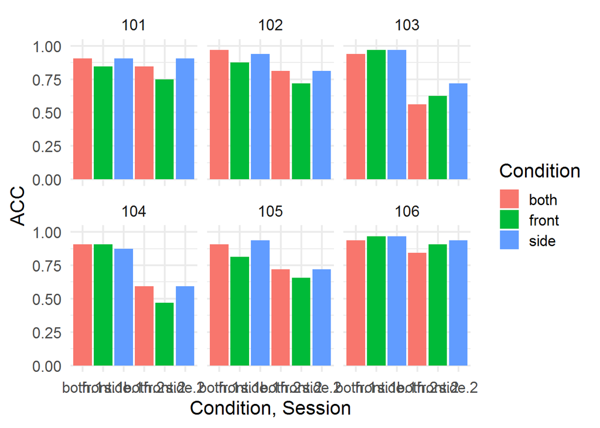

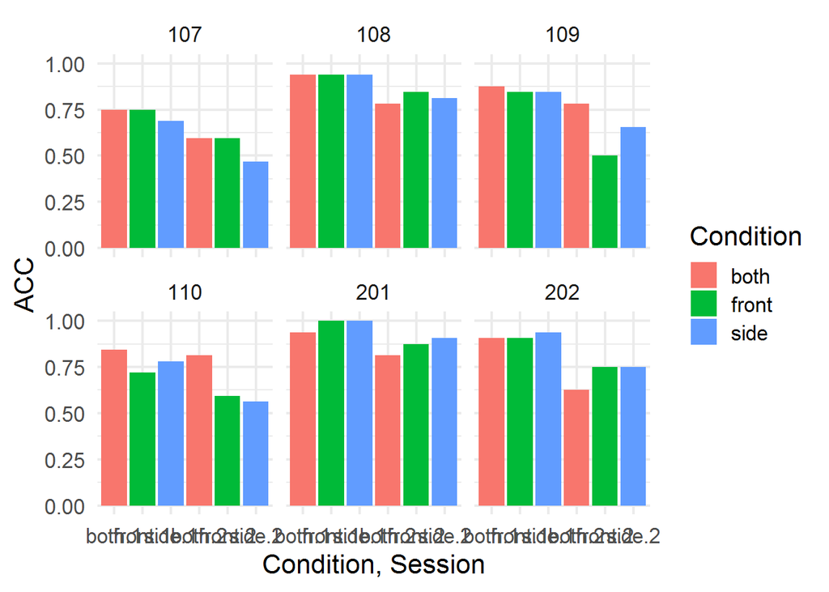

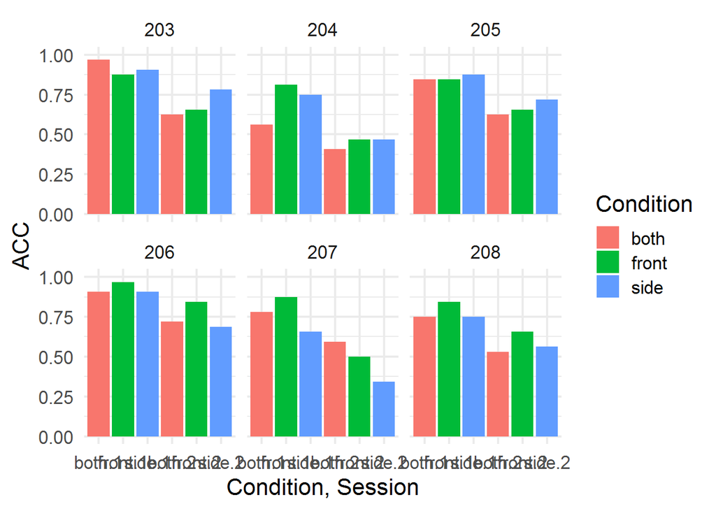

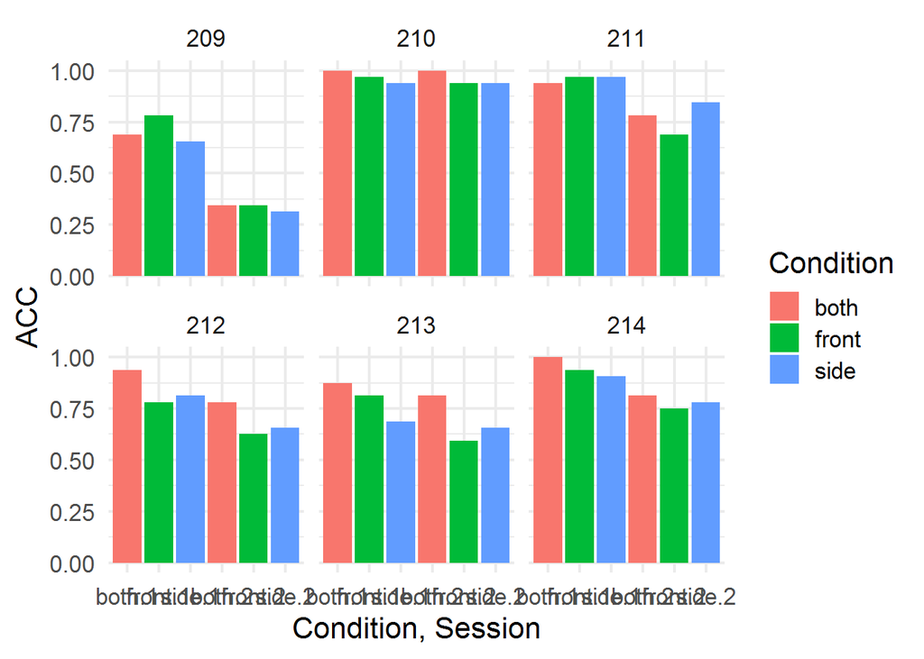

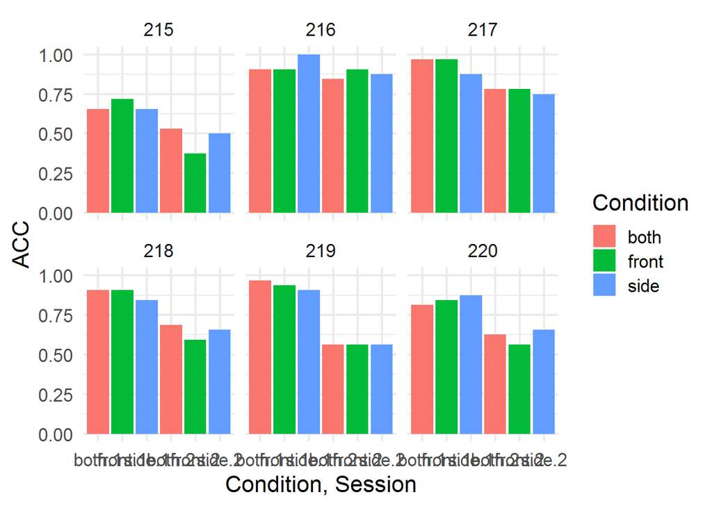

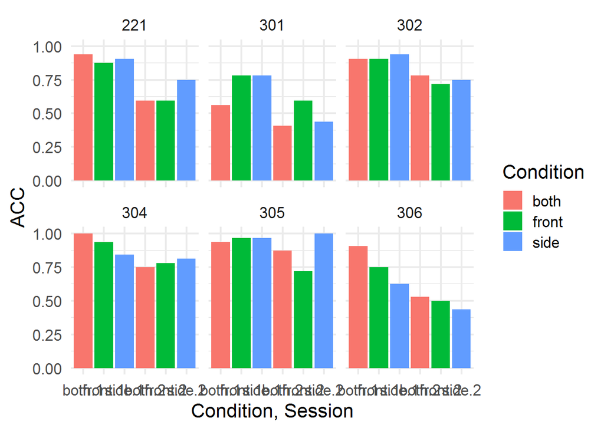

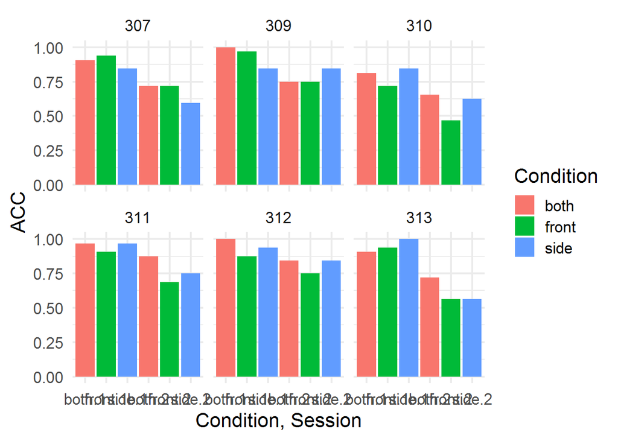

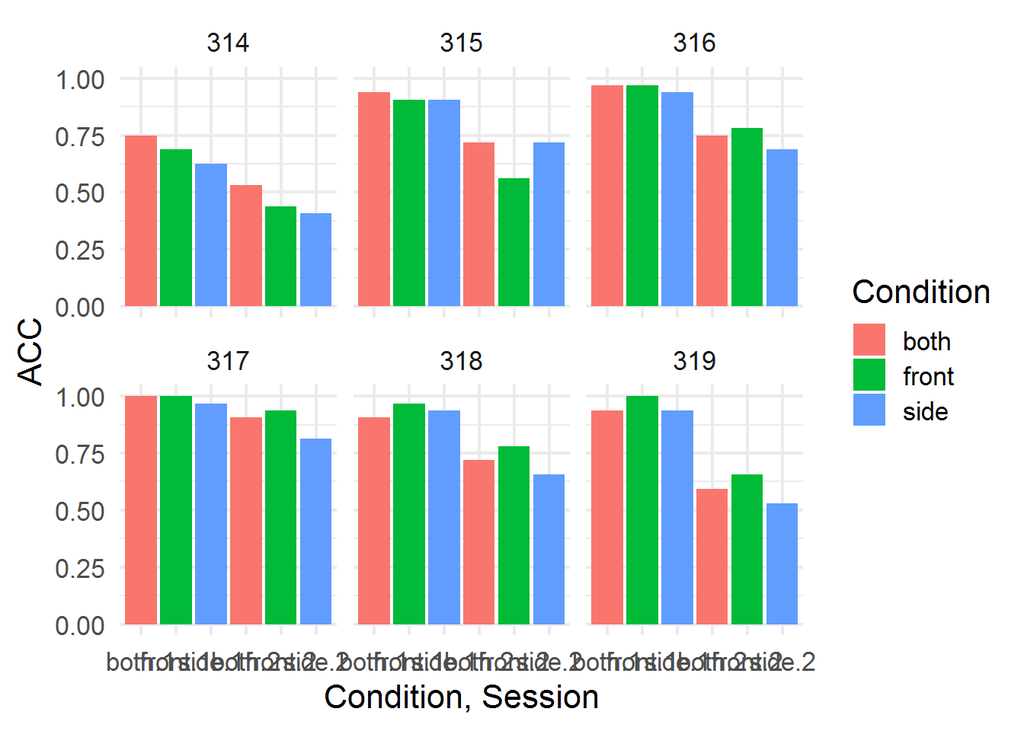

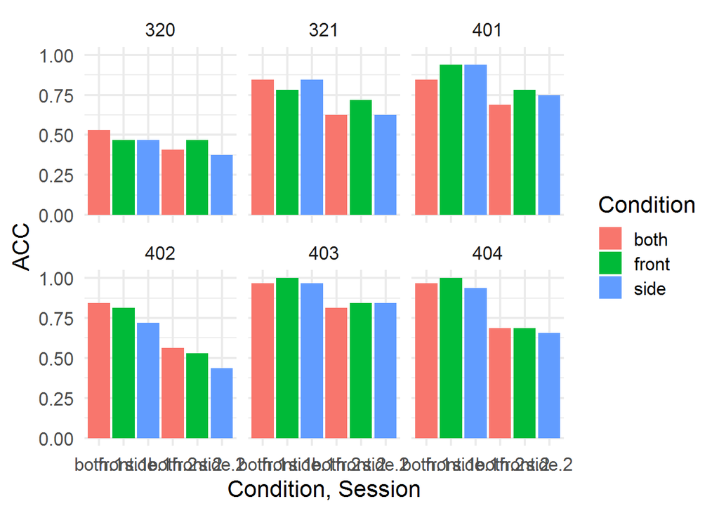

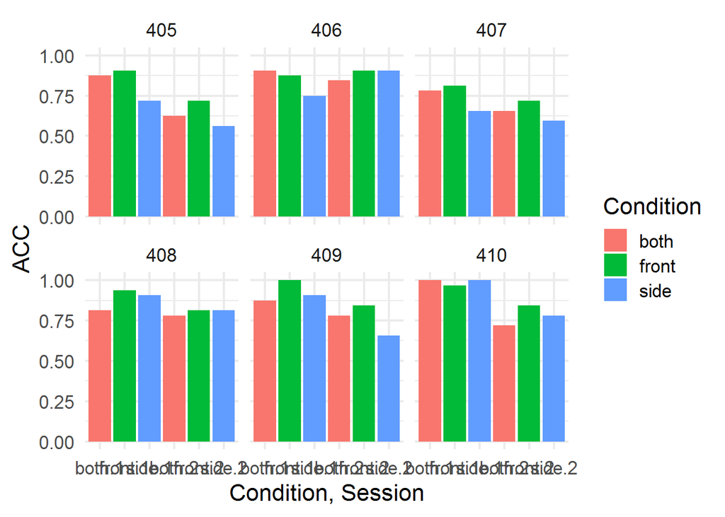

```r
for (i in seq_along(cut_cats)) {
  these_subjects <- all_subjects[cuts == cut_cats[i]]
  ppt_acc_plot <- ppt_acc %>% filter(Subject %in% these_subjects) %>%
    ggplot(aes(x = interaction(Condition, Session), y = ACC, fill = Condition)) + geom_bar(stat = 'identity') +
  facet_wrap(~Subject) +
  xlab('Condition, Session') +
  coord_cartesian(ylim = c(0, 1)) +
  theme_minimal(base_size = 16)
  print(ppt_acc_plot)
}
```

Create individual subject plots for RT:

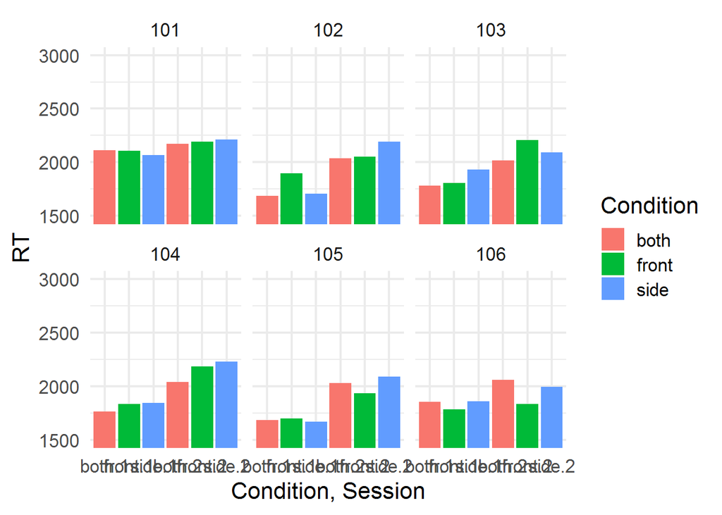

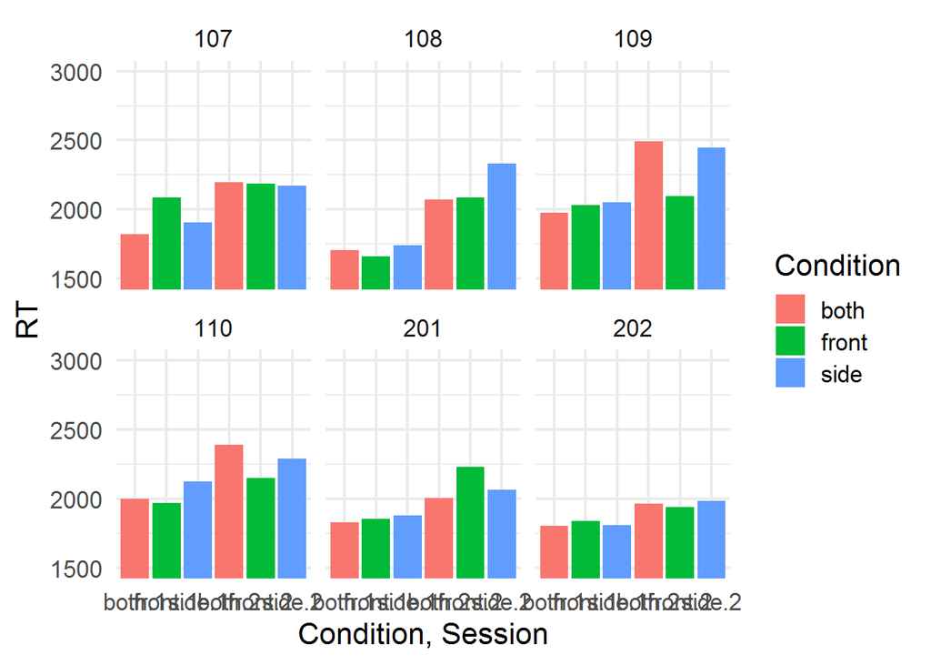

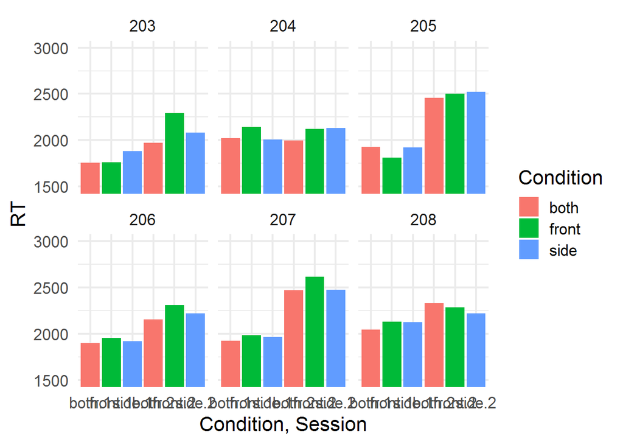

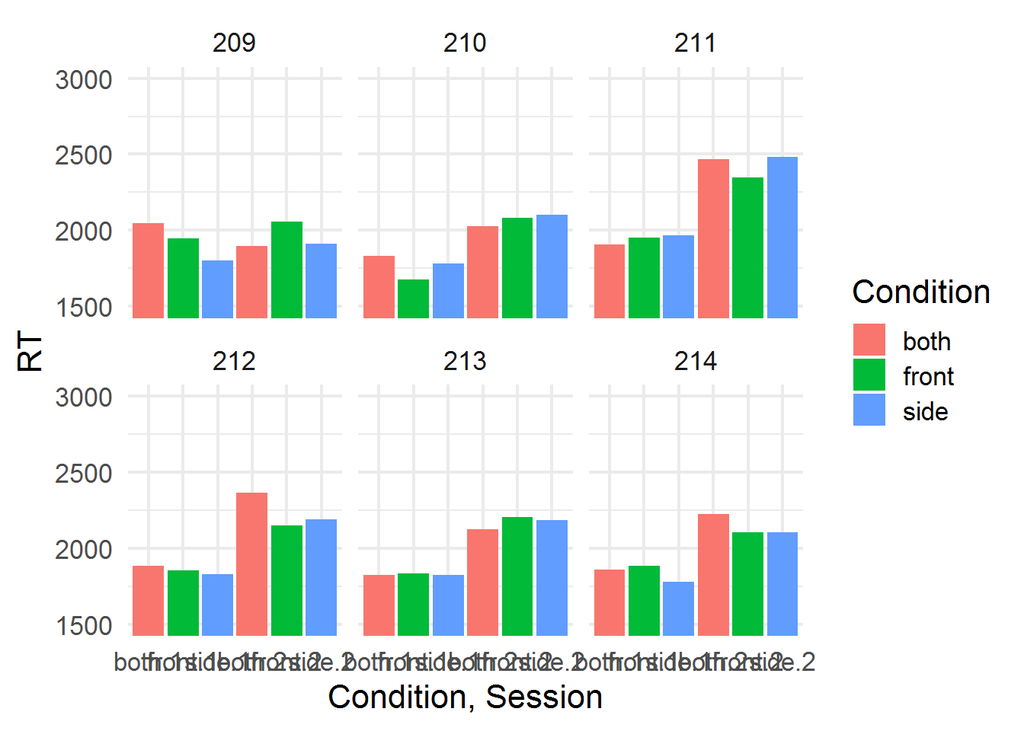

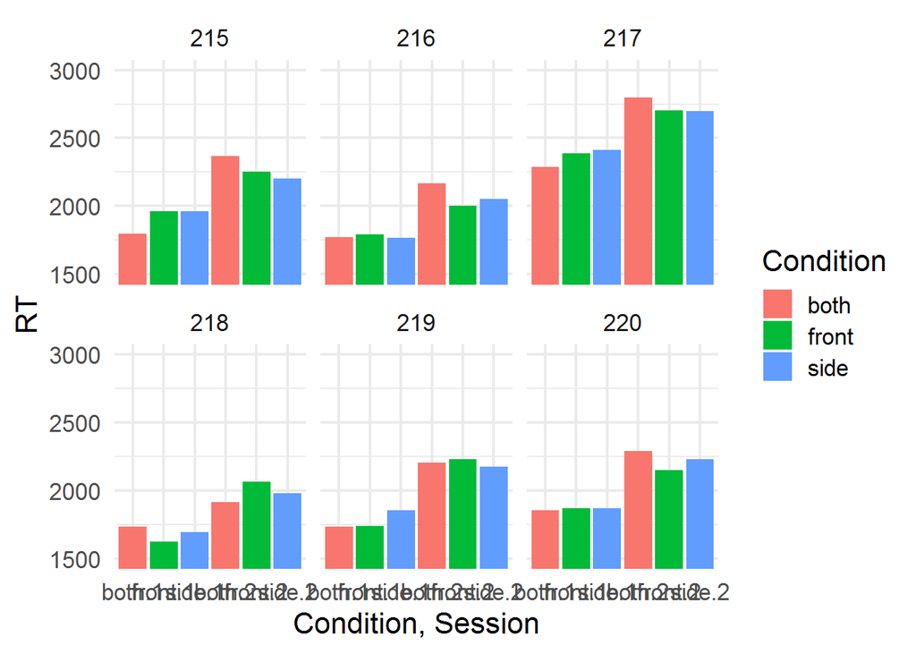

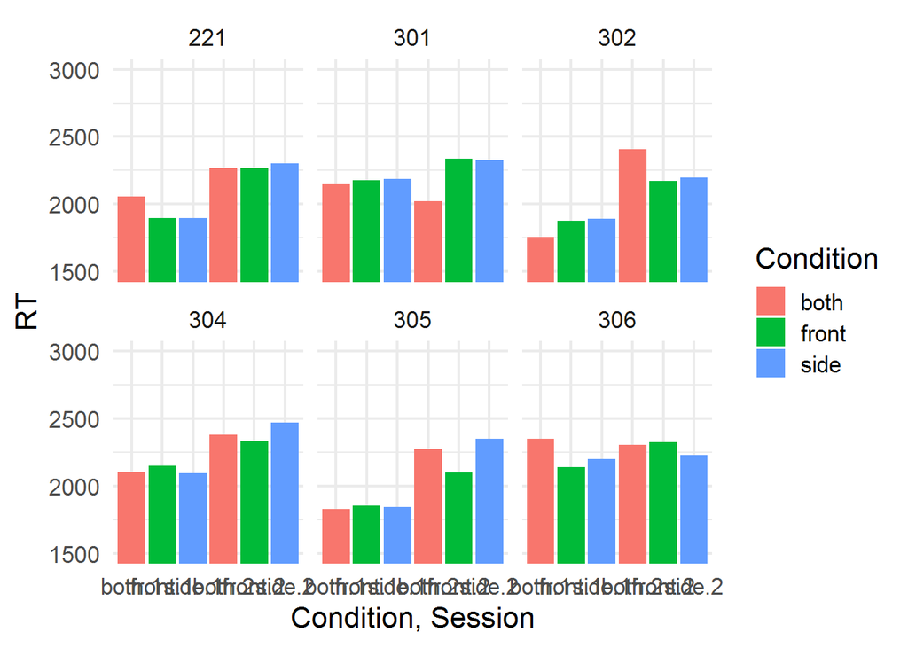

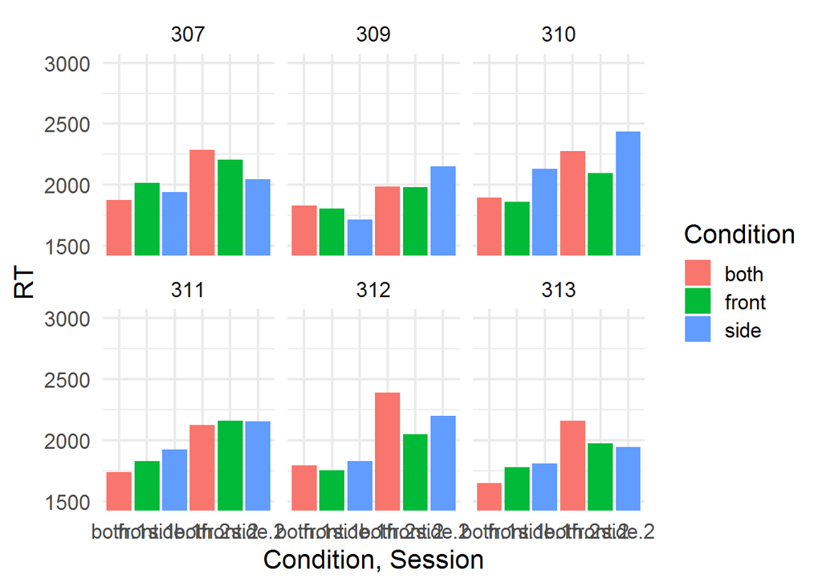

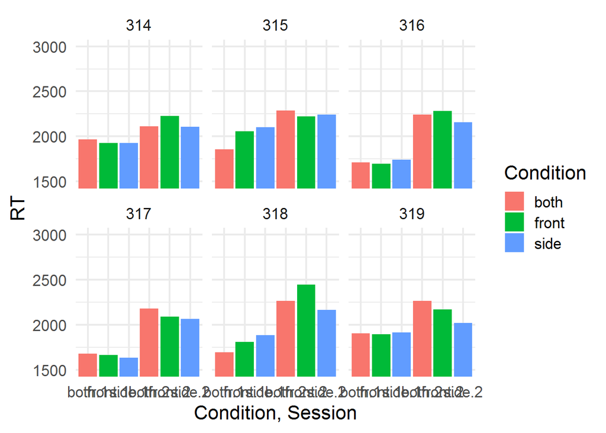

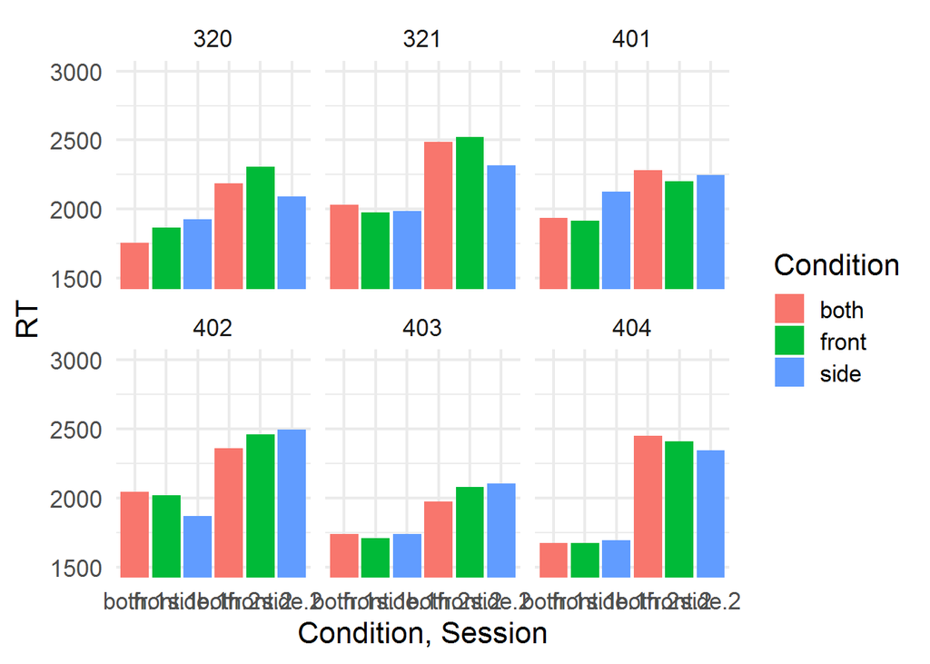

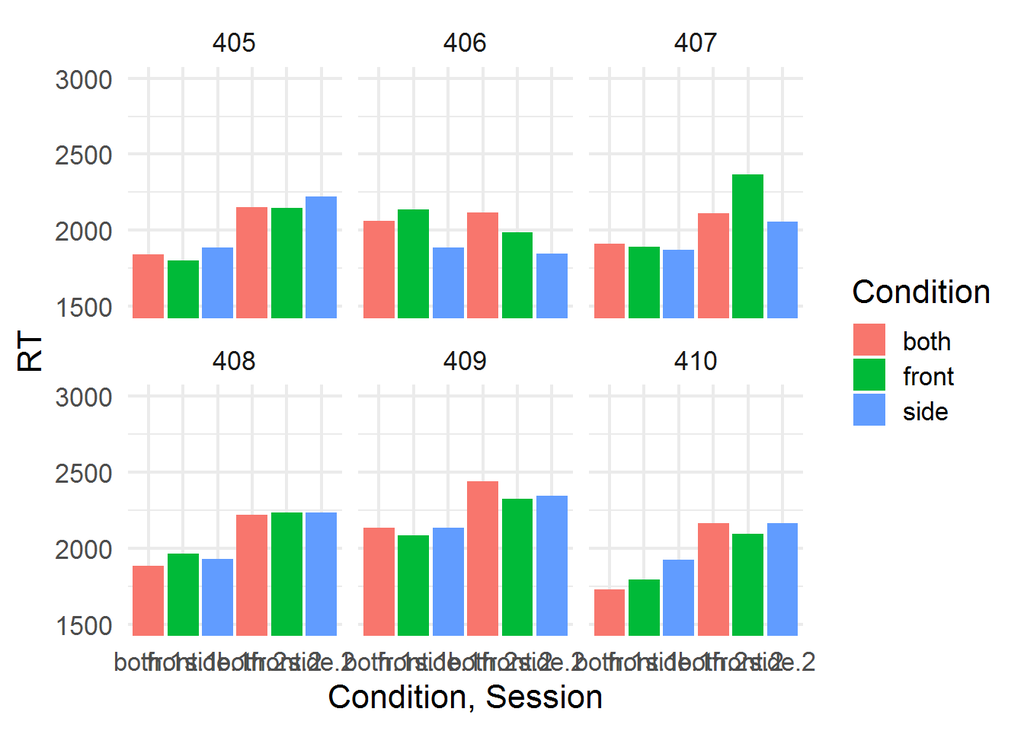

```r
for (i in seq_along(cut_cats)) {
  these_subjects <- all_subjects[cuts == cut_cats[i]]
  ppt_rt_plot <- ppt_rt %>% filter(Subject %in% these_subjects) %>%
  ggplot(aes(x = interaction(Condition, Session), y = RT, fill = Condition)) + geom_bar(stat = 'identity') +
  facet_wrap(~Subject) +
  xlab('Condition, Session') +
  coord_cartesian(ylim = c(1500, 3000)) +
  theme_minimal(base_size = 16)
  print(ppt_rt_plot)
}
```

## Mental Rotation analysis

Load mental rotation data:

```r
mr_data <- read_csv("2019-07-10 AngleLearningMRData.csv")
```

```r
mr_data <- filter(mr_data, type != "PRACTICE")
mr_data <- rename(mr_data, Subject = subNum)
mr_data$Subject <- as.factor(mr_data$Subject)
mr_data
```

```
## # A tibble: 7,680 x 9
##    Subject type  trialnum  cond stimid   rot resp        cor    rt
##    <fct>   <chr>    <dbl> <dbl>  <dbl> <dbl> <chr>     <dbl> <dbl>
##  1 101     TEST         1     1      2    -2 <TIMEOUT>     0  3001
##  2 101     TEST         2     1      2     1 <TIMEOUT>     0  3001
##  3 101     TEST         3     1      1     3 <TIMEOUT>     0  3001
##  4 101     TEST         4     0      2     1 <LSHIFT>      1  2580
##  5 101     TEST         5     1      1     2 <RSHIFT>      1  2007
##  6 101     TEST         6     0      1     2 <LSHIFT>      1  2062
##  7 101     TEST         7     1      2     4 <RSHIFT>      1  1670
##  8 101     TEST         8     1      1     4 <TIMEOUT>     0  3001
##  9 101     TEST         9     0      1     2 <LSHIFT>      1  2516
## 10 101     TEST        10     1      2     1 <RSHIFT>      1  1502
## # ... with 7,670 more rows
```

```r
#mr_data <- filter(mr_data, Subject != 215)
#mr_data <- filter(mr_data, Subject != 314)
#mr_data <- filter(mr_data, Subject != 320)
#mr_data
```

Check number of subjects and how many data points per subjects:

```r
length(unique(mr_data$Subject))
```

```
## [1] 60
```

```r
summary(mr_data$Subject)
```

```
## 101 102 103 104 105 106 107 108 109 110 201 202 203 204 205 206 207 208
## 128 128 128 128 128 128 128 128 128 128 128 128 128 128 128 128 128 128
## 209 210 211 212 213 214 215 216 217 218 219 220 221 301 302 304 305 306
## 128 128 128 128 128 128 128 128 128 128 128 128 128 128 128 128 128 128
## 307 309 310 311 312 313 314 315 316 317 318 319 320 321 401 402 403 404
## 128 128 128 128 128 128 128 128 128 128 128 128 128 128 128 128 128 128
## 405 406 407 408 409 410
## 128 128 128 128 128 128
```

Summarise accuracy per subject:

```r
mr_Acc <- mr_data %>% group_by(Subject) %>%
  summarise(MR_ACC = mean(cor))
print(mr_Acc)
```

```
## # A tibble: 60 x 2
##    Subject MR_ACC
##    <fct>    <dbl>
##  1 101      0.891
##  2 102      0.844
##  3 103      0.742
##  4 104      0.656
##  5 105      0.695
##  6 106      0.664
##  7 107      0.695
##  8 108      0.742
##  9 109      0.727
## 10 110      0.820
## # ... with 50 more rows
```

# RT responses

Filter out incorrect trials:

```r
mr_RT_data <- filter(mr_data, cor == 1)
mr_RT_data
```

```
## # A tibble: 5,478 x 9
##    Subject type  trialnum  cond stimid   rot resp       cor    rt
##    <fct>   <chr>    <dbl> <dbl>  <dbl> <dbl> <chr>    <dbl> <dbl>
##  1 101     TEST         4     0      2     1 <LSHIFT>     1  2580
##  2 101     TEST         5     1      1     2 <RSHIFT>     1  2007
##  3 101     TEST         6     0      1     2 <LSHIFT>     1  2062
##  4 101     TEST         7     1      2     4 <RSHIFT>     1  1670
##  5 101     TEST         9     0      1     2 <LSHIFT>     1  2516
##  6 101     TEST        10     1      2     1 <RSHIFT>     1  1502
##  7 101     TEST        11     1      1     2 <RSHIFT>     1  2230
##  8 101     TEST        12     0      1    -1 <LSHIFT>     1  1575
##  9 101     TEST        13     0      2    -3 <LSHIFT>     1  1976
## 10 101     TEST        14     1      1     3 <RSHIFT>     1  2232
## # ... with 5,468 more rows
```

Filter out reaction times below 500ms:

```r
mr_RT_data <- filter(mr_RT_data, rt > 500)
mr_RT_data
```

```
## # A tibble: 5,412 x 9
##    Subject type  trialnum  cond stimid   rot resp       cor    rt
##    <fct>   <chr>    <dbl> <dbl>  <dbl> <dbl> <chr>    <dbl> <dbl>
##  1 101     TEST         4     0      2     1 <LSHIFT>     1  2580
##  2 101     TEST         5     1      1     2 <RSHIFT>     1  2007
##  3 101     TEST         6     0      1     2 <LSHIFT>     1  2062
##  4 101     TEST         7     1      2     4 <RSHIFT>     1  1670
##  5 101     TEST         9     0      1     2 <LSHIFT>     1  2516
##  6 101     TEST        10     1      2     1 <RSHIFT>     1  1502
##  7 101     TEST        11     1      1     2 <RSHIFT>     1  2230
##  8 101     TEST        12     0      1    -1 <LSHIFT>     1  1575
##  9 101     TEST        13     0      2    -3 <LSHIFT>     1  1976
## 10 101     TEST        14     1      1     3 <RSHIFT>     1  2232
## # ... with 5,402 more rows
```

Summarise RT per subject of correct trials:

```r
mr_RT <- mr_RT_data %>% group_by(Subject) %>%
  summarise(MR_RT = mean(rt))
print(mr_RT)
```

```
## # A tibble: 60 x 2
##    Subject MR_RT
##    <fct>   <dbl>
##  1 101     1780.
##  2 102     1606.
##  3 103     1308.
##  4 104     1617.
##  5 105     1408.
##  6 106     1446.
##  7 107     1490.
##  8 108     1254.
##  9 109     2093.
## 10 110     1529.
## # ... with 50 more rows
```

Bind BSL & MR tibbles:

```r
AccS1Corr<- bind_cols(mr_Acc, ppt_acc_S1)
print(AccS1Corr)
```

```
## # A tibble: 60 x 4
##    Subject MR_ACC Subject1   ACC
##    <fct>    <dbl> <fct>    <dbl>
##  1 101      0.891 101      0.885
##  2 102      0.844 102      0.927
##  3 103      0.742 103      0.958
##  4 104      0.656 104      0.896
##  5 105      0.695 105      0.885
##  6 106      0.664 106      0.958
##  7 107      0.695 107      0.729
##  8 108      0.742 108      0.938
##  9 109      0.727 109      0.854
## 10 110      0.820 110      0.781
## # ... with 50 more rows
```

```r
AccS2Corr<- bind_cols(mr_Acc, ppt_acc_S2)
print(AccS2Corr)
```

```
## # A tibble: 60 x 4
##    Subject MR_ACC Subject1   ACC
##    <fct>    <dbl> <fct>    <dbl>
##  1 101      0.891 101      0.833
##  2 102      0.844 102      0.781
##  3 103      0.742 103      0.635
##  4 104      0.656 104      0.552
##  5 105      0.695 105      0.698
##  6 106      0.664 106      0.896
##  7 107      0.695 107      0.552
##  8 108      0.742 108      0.812
##  9 109      0.727 109      0.646
## 10 110      0.820 110      0.656
## # ... with 50 more rows
```

```r
RTS1Corr <- bind_cols(mr_RT, ppt_rt_S1)
print(RTS1Corr)
```

```
## # A tibble: 60 x 4
##    Subject MR_RT Subject1    RT
##    <fct>   <dbl> <fct>    <dbl>
##  1 101     1780. 101      2095.
##  2 102     1606. 102      1758.
##  3 103     1308. 103      1841.
##  4 104     1617. 104      1812.
##  5 105     1408. 105      1682.
##  6 106     1446. 106      1833.
##  7 107     1490. 107      1940.
##  8 108     1254. 108      1702.
##  9 109     2093. 109      2019.
## 10 110     1529. 110      2031.
## # ... with 50 more rows
```

```r
RTS2Corr <- bind_cols(mr_RT, ppt_rt_S2)
print(RTS2Corr)
```

```
## # A tibble: 60 x 4
##    Subject MR_RT Subject1    RT
##    <fct>   <dbl> <fct>    <dbl>
##  1 101     1780. 101      2192.
##  2 102     1606. 102      2094.
##  3 103     1308. 103      2107.
##  4 104     1617. 104      2148.
##  5 105     1408. 105      2019.
##  6 106     1446. 106      1959.
##  7 107     1490. 107      2187.
##  8 108     1254. 108      2163.
##  9 109     2093. 109      2375.
## 10 110     1529. 110      2288.
## # ... with 50 more rows
```

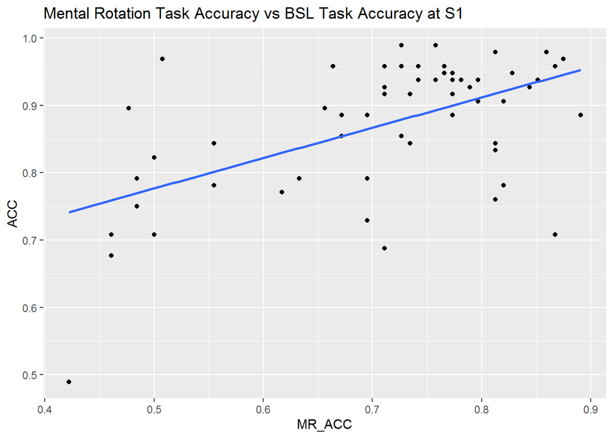

```r
ggplot(AccS1Corr, aes(x=MR_ACC, y=ACC)) +
  geom_point() +
  geom_smooth(method=lm,se=FALSE) +
  ggtitle('Mental Rotation Task Accuracy vs BSL Task Accuracy at S1')
```

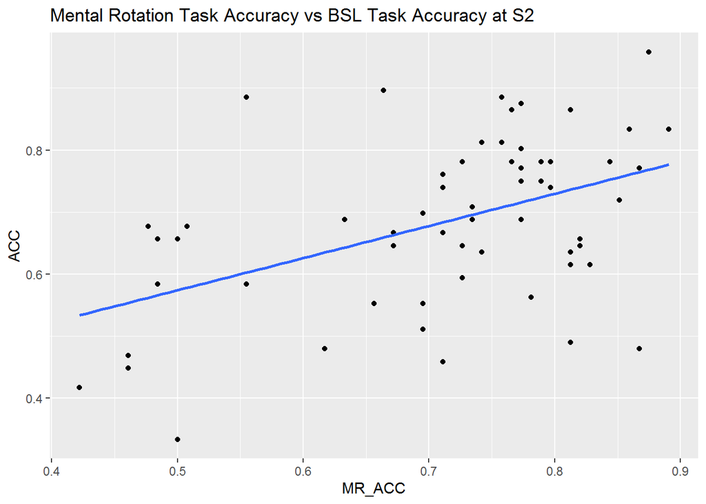

```r
ggplot(AccS2Corr, aes(x=MR_ACC, y=ACC)) +
  geom_point() +
  geom_smooth(method=lm,se=FALSE) +
  ggtitle('Mental Rotation Task Accuracy vs BSL Task Accuracy at S2')
```

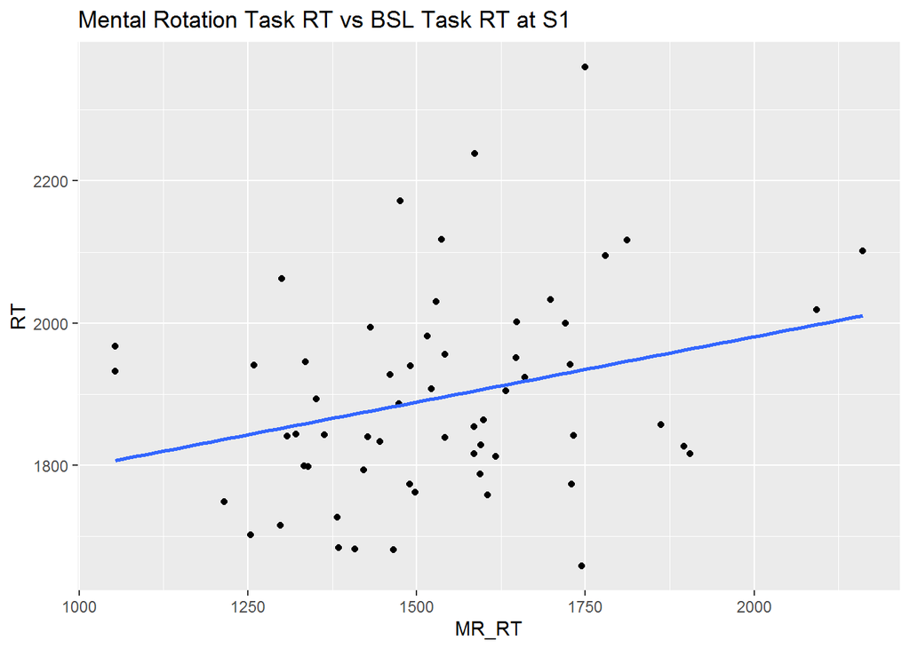

```r
ggplot(RTS1Corr, aes(x=MR_RT, y=RT)) +
  geom_point() +
  geom_smooth(method=lm,se=FALSE) +
  ggtitle('Mental Rotation Task RT vs BSL Task RT at S1')
```

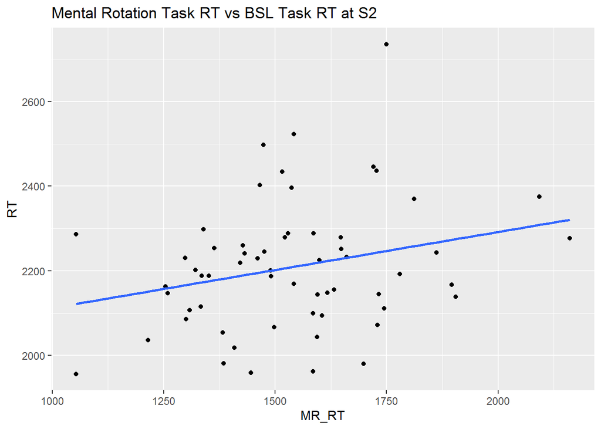

```r
ggplot(RTS2Corr, aes(x=MR_RT, y=RT)) +
  geom_point() +
  geom_smooth(method=lm,se=FALSE) +
  ggtitle('Mental Rotation Task RT vs BSL Task RT at S2')
```

Compute correlations between BSL task & Mental Rotation task for Accuracy & RT (by Session):

```r
AccS1Corr %>% summarize(AccS1COR=cor(MR_ACC,ACC))
```

```
## # A tibble: 1 x 1
##   AccS1COR
##      <dbl>
## 1    0.554
```

```r
AccS2Corr %>% summarize(AccS2COR=cor(MR_ACC,ACC))
```

```
## # A tibble: 1 x 1
##   AccS2COR
##      <dbl>
## 1    0.468
```

```r
RTS1Corr %>% summarize(RTS1COR=cor(MR_RT,RT))
```

```
## # A tibble: 1 x 1
##   RTS1COR
##     <dbl>
## 1   0.280
```

```r
RTS2Corr %>% summarize(RTS2COR=cor(MR_RT,RT))
```

```
## # A tibble: 1 x 1
##   RTS2COR
##     <dbl>
## 1   0.259
```